# A3: SPL Library Checkouts

### Introduction

For this assignment, I want to look at the most popular authors based on the Seattle Public Library Checkout data. Specifically, I will be comparing the five most checked-out authors for both physical books and digital alternatives over the past few years. I chose to examine physical books separate from ebooks and audiobooks because I’m curious if the medium of books will affect which authors are most popular. This could raise interesting questions like if some author’s works are better experienced through digital mediums. After that, I will break down the genres of each book the most popular authors wrote to see if there is any takeaway about the most popular genres in Seattle library users.

### Summary Information

The library has 12735615 items that are missing an author or creator. Of those 6305732 are physical books, 4044 are ebooks, and 48 are audiobooks. The other 29297593 items are all credited with an author or creator. That is the data that this assignment will analyze. The most popular book overall among the three mediums is Educated: A Memoir, which was written by Tara Westover.

### The Dataset

This dataset was collected and published by the Seattle Public Library. The dataset tracks all checkouts from the library, which includes books (of all kinds), music, discs (video and sound), and various other library resources. For each item, the dataset tracks: - the usage class of each item - the way it was checked out - the type of item it was - the month and year it was checked out - the amount of times it was checked out for the respective month and year - the name or title of the item - the ISBN (International Standard Book Number) if applicable - the item’s creator or author - the item’s subject or genre - the publisher - and the publication date (typically just the year) This data was generated from the library’s system tracking the movement of resources that were logged. This dataset began in April of 2005 and was last updated February 6, 2023. This dataset doesn’t track any specific people so privacy isn’t a concern. Instead, since this dataset is messy, the biggest ethical concerns while using it are likely related to copyright and proper credit, as many accomplished creators’ works could be buried under inefficient labeling. This dataset only tracks behavior logged in the Seattle Public Library’s system, and as such is somewhat limited in scope. This means the data can’t be used to make assumptions about book popularity as a whole. There are a lot of items with missing values as well, which should be taken into consideration when analyzing the dataset.

### First Trends Over Time Chart

This chart is a trends-over-time chart that looks at the five most popular authors in the Seattle Public Library Database based on book checkouts. These authors were selected by having the highest total all-time checkout counts, and they are compared using their checkout count for each year between 2005 and 2022. For this chart I only looked at physical book checkouts because I wanted to compare these results to other formats.

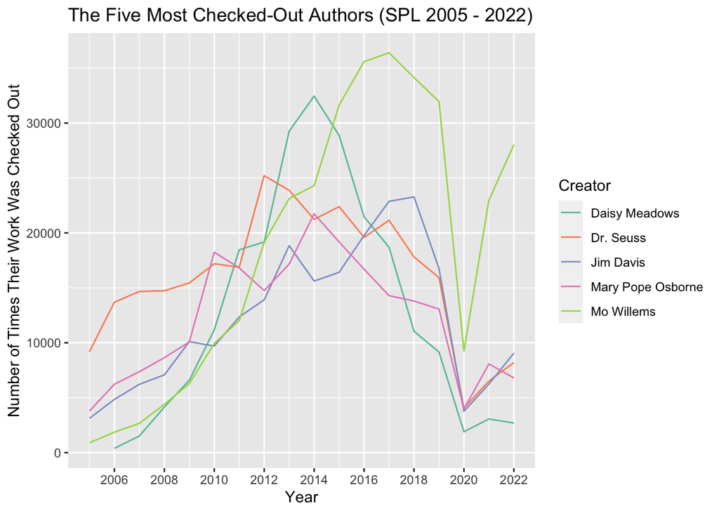

### Second Trends Over Time Chart

This chart is a trends-over-time chart that looks at the five most popular creators in the Seattle Public Library Database based on ebook and audiobook checkouts. These authors were selected by having the highest total all-time checkout counts, and they are compared using their checkout count for each year between 2005 and 2022. For this chart I explored ebook and audiobook creators, because I wanted to see if the different medium would affect author checkout rates.

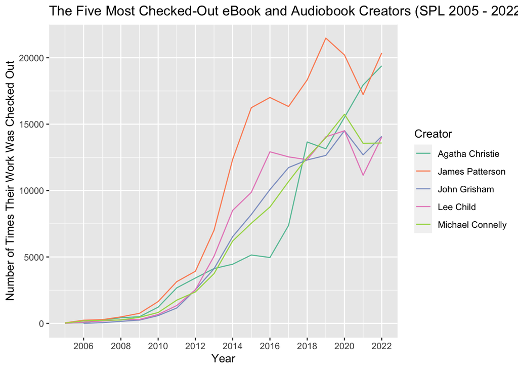

### Stacked Bar Chart

This final chart is a stacked bar chart that compares the top creators of physical books to the top creators of ebooks and audiobooks. Since there is already data in the previous charts related to their checkout counts, I wanted to instead explore the amount of works each creator has in the library, as well as the popular genres among the creators.

This chart showed a major outlier in book amount from James Patterson, and that overall popular authors tended to have a large amount of works, but that it wasn’t a requirement. As for genres, the data was very messy, and so the most popular genre was just the generic label of “Fiction”. There were a couple interesting genres in the top ten for these creators, which included African American Fiction, Law, and True Crime.

This chart is a very rough, as the data involved was very messy. These only look at each authors physical or ebook counts respectively, rather than everything they have in the library. The book count is an approximation as well, as the library database has a large amount of repeat entries. I mostly combined the repeats, but at the cost of lumping together a lot of book series into one entry. The genre information is also very rough, as many books had unique subjects exlusive to their creator or series. This chart also ignores books tagged with more than one genre.

[figure not shown]